# Data Visualization in R

From data to publication-ready static figures

Siddhartha Bora · West Virginia University

May 28, 2026

# Welcome

## Follow along

All materials live here:

[**github.com/SiddharthaSBora/r-dataviz-webinar**](https://github.com/SiddharthaSBora/r-dataviz-webinar)

- 📊 Slide deck: `slides/`
- 💻 Live-coding companion: `live-coding/`
- 📋 One-page cheatsheet: `cheatsheet/`
- 🧪 21 standalone demo scripts: `demos/`

*Open the repo now if you want to run code along with the talk.*

`git clone https://github.com/SiddharthaSBora/r-dataviz-webinar`

## Our goals for today

Discuss/practice:

- **A workflow** for going from raw data to a polished static figure in R
- **The reasoning** behind design choices: color, type, layout, accessibility
- **A working knowledge of maps in R**: the part most people find annoying

This is a general R dataviz talk. The map content suits anyone doing regional comparisons, and the principles apply generally.

## Two things before we start

- **I’m just another R user.** I use these tools day to day and I’m sharing what works for me.
- **This is opinionated.** There are many ways to do everything here. These are choices, not rules, take what’s useful and leave the rest.

## A note on editors

None of this depends on your editor, the code is identical everywhere.

- **RStudio** — what I use, and what you’ll see today. The classic R IDE.
- **VS Code** — I use it too; solid with the R extension if you already live there.
- **Positron** — Posit’s newer IDE, a VS Code–based successor to RStudio. Many people are making the switch.

Pick whatever keeps you productive, everything here runs the same in all three. With that, let’s get into it.

# Part 0: How to think about data viz

This section follows the arc of *R for Data Science (2e)*, chapters 1–11, free at [r4ds.hadley.nz](https://r4ds.hadley.nz/)

## Why visualize *first*?

R4DS teaches `ggplot` in **chapter 1**, before any data wrangling.

Visualization is how you *understand* data, as much as how you present it.

**Anscombe’s quartet**, four datasets with nearly identical means, variances, and correlations…

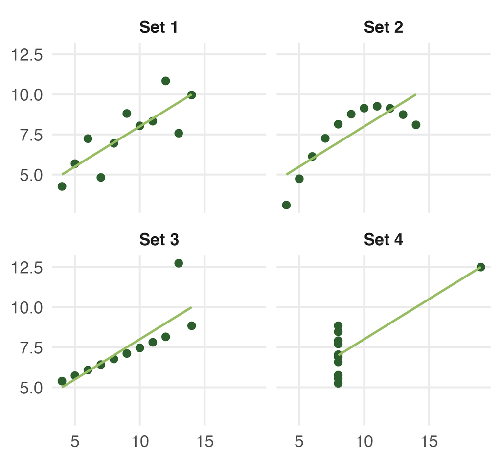

…yet they look **completely different**. Summary statistics can mislead; pictures don’t. **Plot early, plot often.**

## Tidy data: the foundation

Three rules *(R4DS Ch. 5)*:

1. Each **variable** is a column
2. Each **observation** is a row
3. Each **value** is a cell

Tidy data is what lets every downstream step (transform, plot, model) work with the same tools.

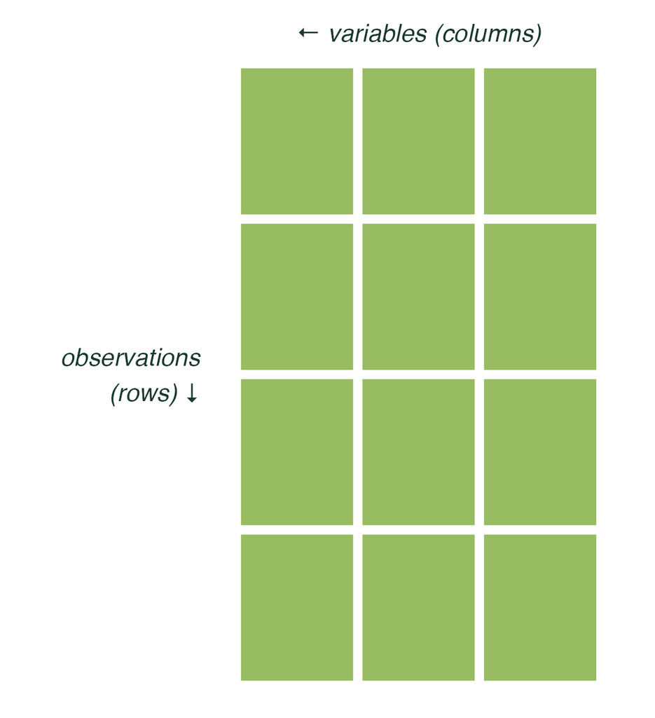

> “Tidy datasets are all alike; every messy dataset is messy in its own way.” (Wickham)

## Data wrangling: the real work

Before any plot, the data has to be **tidy**. In practice, getting it there is the **biggest challenge**, often most of the work.

The everyday verbs *(R4DS Ch. 3 & 5)*:

- **`filter()`** — keep rows
- **`select()`** — keep columns
- **`mutate()`** — add / change columns
- **`group_by()` + `summarise()`** — aggregate
- **`pivot_longer()` / `pivot_wider()`** — reshape
- **`*_join()`** — combine tables

**Real data is messy:**

- Values stored in column names
- One cell holding two variables
- Dates and numbers stored as text
- Missing values, inconsistent labels
- Several tables that must be joined

We won’t go deep today, it’s a topic of its own. Just know: **if a plot feels hard, the fix is usually upstream, in the data.**

A whole subject in itself, see *R for Data Science (2e)*, chapters 3 (transform) and 5 (tidy).

## Aesthetic mappings & how we read them

**Mapping** = assigning a data variable to a visual channel:

- `x`, `y` → **position**
- `color`, `fill` → hue
- `shape`, `linetype` → form
- `size` → area

*(R4DS Ch. 1 & 9)*

**But we don’t read all channels equally well.**

Accuracy of human perception, best → worst:

1. Position along a scale
2. Length
3. Angle / slope
4. Area
5. Color / shade / density

This is *why* bar charts beat pie charts, and why color should carry **categories or emphasis**, not precise quantities.

Cleveland & McGill (1984), graphical perception. Echoed throughout R4DS Ch. 9–11.

## Exploratory data analysis (EDA)

EDA is a **mindset**, not a checklist *(R4DS Ch. 10)*:

- Generate questions about your data
- Search for answers by visualizing, transforming, and modeling
- Use what you learn to refine the questions: and repeat

Two questions drive most of it:

- What type of **variation** occurs within my variables?
- What type of **covariation** occurs between my variables?

> “EDA is not a formal process with a strict set of rules… it is a state of mind.” (R4DS)

The plots you make *for yourself* (fast, ugly, many) differ from the ones you make *for others* (slow, polished, few).

## Communication

The shift from **exploratory** (for you) to **explanatory** (for others) *(R4DS Ch. 11)*:

**Exploratory plot**

- Default labels
- Default colors
- Made in seconds
- Audience: you

**Explanatory plot**

- Informative title + subtitle
- Deliberate color
- Annotations, source caption
- Audience: everyone else

A figure that communicates needs more than the ggplot default. Most of today’s hands-on portion is this transformation, **layer by layer**.

## Workflow & reproducibility

R4DS interleaves “workflow” chapters *(Ch. 2, 4, 6, 8)*. The craft around the code matters as much as the code:

- **Projects, not `setwd()`** *(Ch. 6)*: your analysis should run on anyone’s machine
- **Readable code style** *(Ch. 4)*: code is read far more often than written
- **Knowing how to get help** *(Ch. 8)*: reprexes, documentation, the community
- **Scripts you can re-run**: reproducibility built in from the start

That’s why this webinar ships as an **R project**, not loose scripts.

## Why R + the tidyverse

The handoff to the hands-on portion:

- The **grammar of graphics** is literally how `ggplot2` is built
- The **tidyverse** is one coherent toolkit for the whole game: import, tidy, transform, visualize, communicate
- **Reproducible**: scriptable, version-controllable, re-runnable
- **Publication-quality** static output, and it’s **free**

We’ve covered the *what* and the *why*.

**Now the *how*.**

# Demos 1–2 · Data first

## Demo 1: Tidy data

`▶ demos/01-tidy-data.R`

**Untidy**, subjects in columns (3 rows)

| student | english | math | science |
| --- | --- | --- | --- |
| 1 | 70 | 87 | 100 |
| 2 | 78 | 65 | 83 |
| 3 | 82 | 91 | 88 |

**Tidy**, one row per (student, subject) (9 rows)

| student | subject | score |
| --- | --- | --- |
| 1 | english | 70 |
| 1 | math | 87 |
| 1 | science | 100 |
| 2 | english | 78 |
| 2 | math | 65 |
| 2 | science | 83 |
| 3 | english | 82 |
| 3 | math | 91 |
| 3 | science | 88 |

**The rules** (Wickham 2014):

1. Each **variable** is a column
2. Each **observation** is a row
3. Each **value** is a cell

**Why we care:** `ggplot2` is *designed* for tidy data. Long form unlocks aesthetic mappings like `color = subject`.

## Demo 2: Long vs wide

`▶ demos/02-long-vs-wide.R`

The same data, two shapes:

```r
library(tidyr)

scores_wide <- tibble(
  student = c(1, 2, 3),
  english = c(70, 78, 82),
  math    = c(87, 65, 91),
  science = c(100, 83, 88)
)

# WIDE -> LONG
scores_long <- scores_wide |>
  pivot_longer(
    cols      = -student,
    names_to  = "subject",
    values_to = "score"
  )

scores_long
```

```
# A tibble: 9 × 3
  student subject score
    <dbl> <chr>   <dbl>
1       1 english    70
2       1 math       87
3       1 science   100
4       2 english    78
5       2 math       65
6       2 science    83
7       3 english    82
8       3 math       91
9       3 science    88
```

## The reverse direction

```r
# LONG -> WIDE
scores_long |>
  pivot_wider(names_from = subject, values_from = score)
```

```
# A tibble: 3 × 4
  student english  math science
    <dbl>   <dbl> <dbl>   <dbl>
1       1      70    87     100
2       2      78    65      83
3       3      82    91      88
```

**Rule of thumb:**

- Storing, analyzing, plotting → **long**
- Final summary table for a human reader → **wide**

> “If your plot feels hard, your data is probably wide.”

# Demo 3 · The grammar of graphics

## In one sentence

`▶ demos/03-first-ggplot.R`

> Map data variables to visual properties (aesthetics) and pick a geometric object (geom) to represent each row.

Every ggplot has three things:

```r
ggplot(data = <DATA>) +
  aes(x = <VAR>, y = <VAR>, color = <VAR>) +
  geom_<TYPE>()
```

- **`data`**: a data frame
- **`aes()`**: mapping from variables to visual properties
- **`geom_*()`**: the visual representation (line, point, bar, polygon…)

## Same data, different geom

```r
p_base <- ggplot(economics, aes(x = date, y = unemploy / 1000))

p_line  <- p_base + geom_line()  + labs(title = "geom_line",  x = NULL, y = "Million")
p_area  <- p_base + geom_area(fill = "#2c5f2d", alpha = 0.6) + labs(title = "geom_area",  x = NULL, y = "Million")
p_point <- p_base + geom_point(alpha = 0.3, size = 0.8) + labs(title = "geom_point", x = NULL, y = "Million")
p_step  <- p_base + geom_step() + labs(title = "geom_step",  x = NULL, y = "Million")

(p_line | p_area) / (p_point | p_step)
```

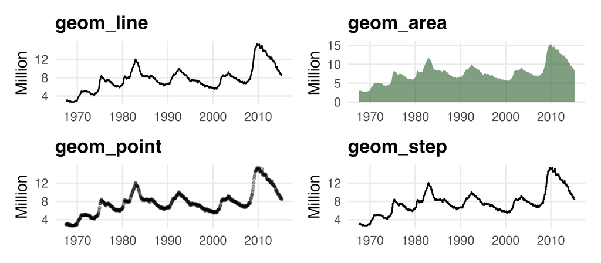

**The data didn’t move. The geom is a *choice* about how to represent it.**

# Demo 4 · A worked example

## The plan

`▶ demos/04-layered-improvement.R`

We’ll take **one** plot from “default ggplot” to “publication ready” by adding **one layer at a time.**

Sample data: life expectancy at birth in three countries, 1990–2020.

```r
life_exp <- life_exp_sample()
life_exp
```

```
# A tibble: 12 × 3
   country  year life_exp
   <chr>   <dbl>    <dbl>
 1 Brazil   1990     65.7
 2 Brazil   2000     70.1
 3 Brazil   2010     73.4
 4 Brazil   2020     75.9
 5 India    1990     58.5
 6 India    2000     62.6
 7 India    2010     66.6
 8 India    2020     70.2
 9 USA      1990     75.2
10 USA      2000     76.8
11 USA      2010     78.5
12 USA      2020     77
```

## Step 1: the crudest possible plot

```r
p1 <- life_exp |>
  ggplot(aes(x = year, y = life_exp, color = country)) +
  geom_line()

p1
```

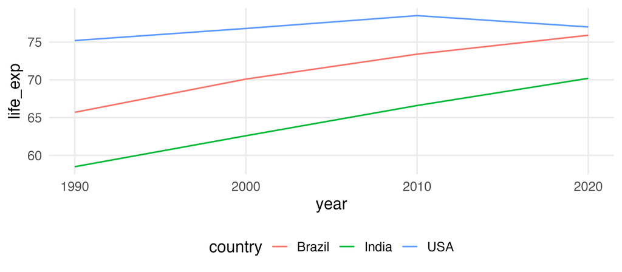

Works. Looks bad. **That’s the point**, every default ggplot looks like this.

## Step 2: treat the plot as an object

The single most powerful idea in ggplot:

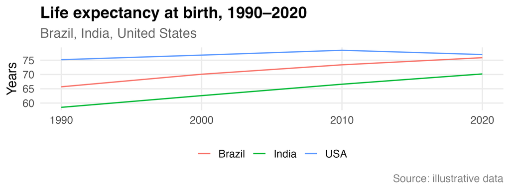

```r
p2 <- p1 +
  labs(
    title    = "Life expectancy at birth, 1990–2020",
    subtitle = "Brazil, India, United States",
    x        = NULL,
    y        = "Years",
    color    = NULL,
    caption  = "Source: illustrative data"
  )

p2
```

**Each `+` is a layer.** You can save plots as objects, add to them later, and reuse them.

## Step 3: thicker lines, end-point markers

```r
# Note: linewidth, not size: ggplot 3.4.0 (2022) deprecated `size` for lines.
p3 <- p2 +
  geom_line(linewidth = 1.1) +
  geom_point(size = 2.5)

p3
```

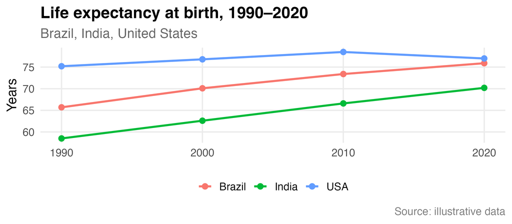

## Step 4: pick a deliberate color palette

```r
# Viridis: perceptually uniform AND colorblind-safe.
p4 <- p3 +
  scale_color_viridis_d(option = "D", end = 0.85)

p4
```

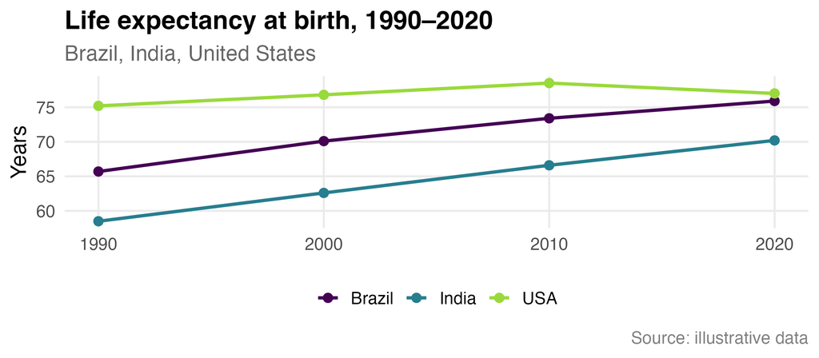

We’ll come back to color choices in a moment.

## Step 5: apply a clean theme

```r
p5 <- p4 +
  theme_minimal(base_size = 13) +
  theme(
    plot.title    = element_text(face = "bold"),
    plot.subtitle = element_text(color = "grey40"),
    legend.position  = "bottom",
    panel.grid.minor = element_blank()
  )

p5
```

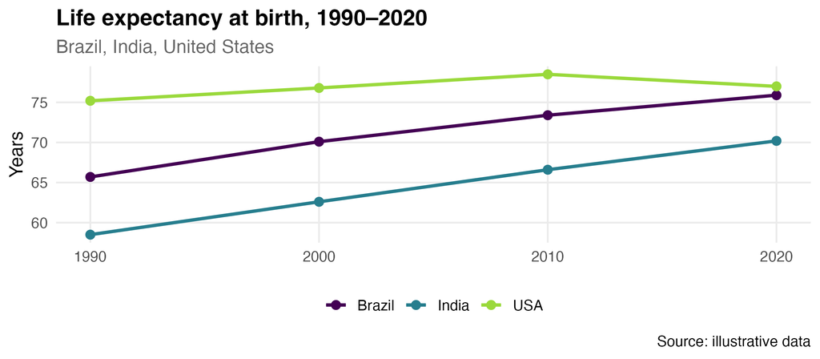

## Step 6: fix axis breaks and limits

```r
p6 <- p5 +
  scale_x_continuous(breaks = seq(1990, 2020, 10)) +
  scale_y_continuous(limits = c(55, 80), labels = scales::label_number(suffix = " yr"))

p6
```

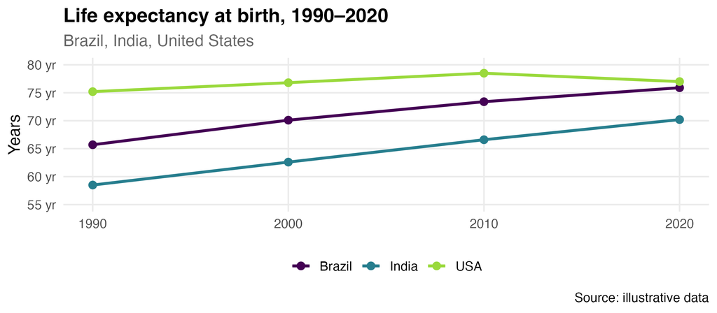

## Before and after

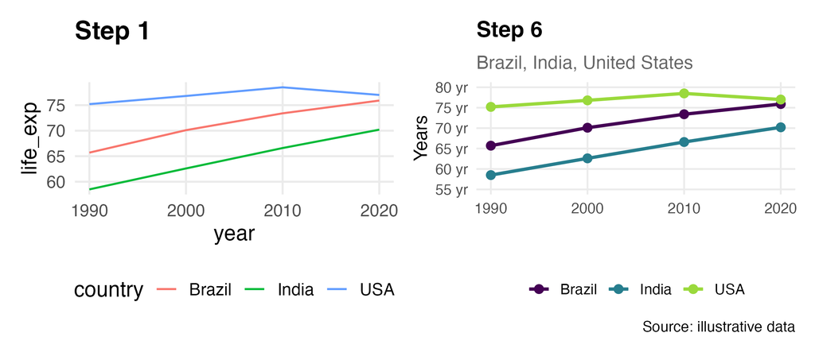

**Six small, named layers. Each one does one thing.**

> You didn’t write a 50-line plotting function. You assembled a figure.

# Demo 5 · Color, done deliberately

## Three kinds of color scale

`▶ demos/05-color-palettes.R`

[figure not shown]

**First pick the *type*, then the palette.** Diverging only when your data has a meaningful midpoint (zero, mean, baseline).

## The palette functions you’ll actually use

| Type | Discrete | Continuous |
| --- | --- | --- |
| Qualitative | `scale_*_brewer(palette = "Set2")` | — |
| Qualitative (colorblind-safe) | `scale_*_viridis_d()`, Okabe-Ito | — |
| Sequential | `scale_*_viridis_d()` | `scale_*_viridis_c()` |
| Sequential (alt) | `scale_*_distiller(palette = "Blues")` | `scale_*_gradient()` |
| Diverging | `scale_*_distiller(palette = "RdBu")` | `scale_*_gradient2()` |
| Manual | `scale_*_manual(values = c(...))` | `scale_*_gradientn(colours = c(...))` |

Replace `*` with `color` or `fill` depending on the aesthetic.

## Default ggplot colors aren’t a great default

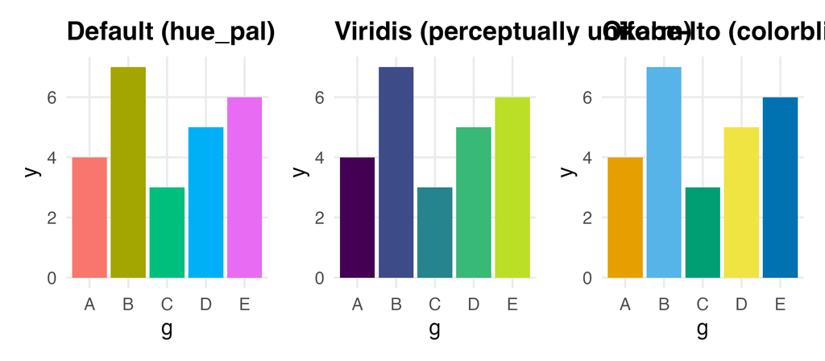

Defaults are *colorful*. They are not *colorblind-safe*, not *perceptually uniform*, and not *meaningful*.

**Pick a palette deliberately.** Once per project, not once per plot.

# Demo 6 · Type, theme, polish

## Built-in themes

`▶ demos/06-themes-and-fonts.R`

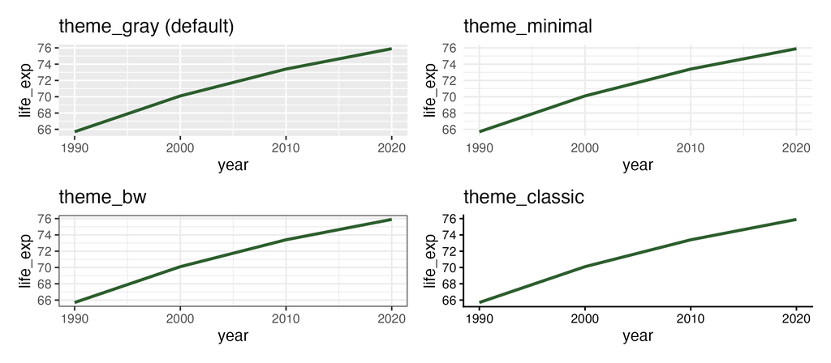

`theme_minimal()` and `theme_classic()` are safe defaults for most published work.

## The `theme()` function: what you actually customize

```r
theme(
  # Titles and captions
  plot.title    = element_text(face = "bold", size = 14),
  plot.subtitle = element_text(color = "grey40"),
  plot.caption  = element_text(color = "grey50", hjust = 0),

  # Axes
  axis.title = element_text(size = 12),
  axis.text  = element_text(size = 10),

  # Legend
  legend.position = "bottom",       # "top", "right", "none", or c(x, y)
  legend.title    = element_blank(),

  # Panel
  panel.grid.minor = element_blank(),
  panel.grid.major.x = element_blank()
)
```

**Tip:** Set a project-wide theme with `theme_set(theme_minimal() + theme(...))` at the top of your script. Then every plot inherits it.

## Format numbers properly: the `scales` package

```r
library(scales)

ggplot(economics, aes(date, unemploy * 1000)) +
  geom_line(linewidth = 1, color = "#2c5f2d") +
  scale_y_continuous(labels = label_number(scale = 1e-6, suffix = "M")) +
  scale_x_date(date_breaks = "10 years", date_labels = "%Y") +
  labs(title = "US unemployed persons", x = NULL, y = NULL)
```

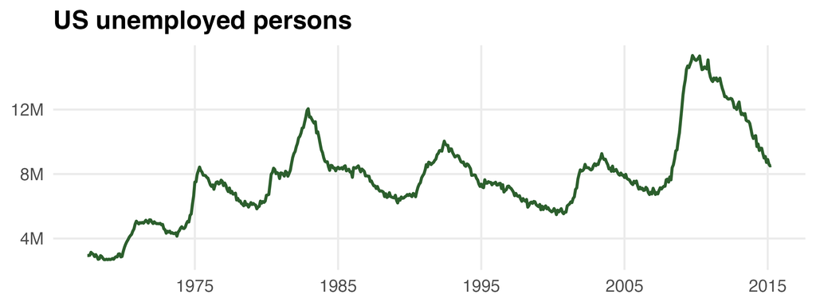

Useful: `label_number()`, `label_percent()`, `label_comma()`, `label_dollar()`, `label_date()`

## Fonts: and the export gotcha

- Fonts that look fine on screen often vanish or substitute in PDF export
- The fix: use the **`ragg`** graphics device for PNG, **`cairo_pdf`** for PDF
- Old advice (`type = "cairo"` in `ggsave`) no longer works: `ragg` replaced it

More in the export section. The device matters.

# Demo 7 · Faceting

## Small multiples

`▶ demos/07-faceting.R`

```r
# Use gapminder if available (more interesting), else fall back to life_exp.
if (requireNamespace("gapminder", quietly = TRUE)) {
  gapminder::gapminder |>
    filter(continent == "Americas",
           country %in% c("Brazil", "Argentina", "Mexico", "Chile",
                          "Colombia", "Peru")) |>
    ggplot(aes(year, lifeExp)) +
    geom_line(linewidth = 1, color = "#2c5f2d") +
    facet_wrap(~ country) +
    labs(title = "Life expectancy, selected Americas",
         x = NULL, y = "Years")
} else {
  life_exp |>
    ggplot(aes(year, life_exp)) +
    geom_line(linewidth = 1, color = "#2c5f2d") +
    geom_point(size = 2, color = "#2c5f2d") +
    facet_wrap(~ country) +
    labs(title = "Life expectancy by country", x = NULL, y = "Years")
}
```

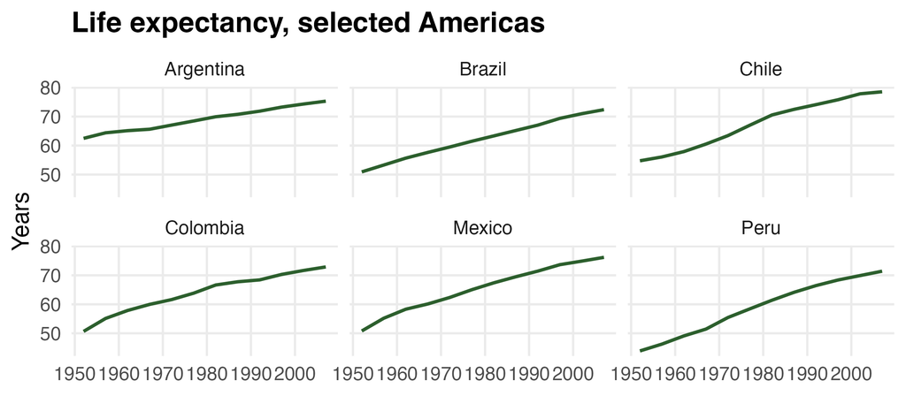

**One crowded plot becomes six clear panels.**

## `facet_wrap` vs `facet_grid`

```r
# Wrap one variable into a grid of panels
ggplot(...) + facet_wrap(~ region)

# Cross two variables: rows by year, columns by region
ggplot(...) + facet_grid(year ~ region)

# Free scales: let each panel pick its own y range
ggplot(...) + facet_wrap(~ region, scales = "free_y")

# Add row/column labels via labeller
ggplot(...) + facet_wrap(~ region, labeller = label_both)
```

> **When in doubt, facet.** Five small clear panels beat one cluttered plot.

# Demo 8 · Accessibility

## Why this matters

`▶ demos/08-accessibility.R`

- **Federal reports** (USDA, NIH, EPA) require Section 508 / ADA compliance
- **Journals** increasingly require accessibility statements
- Accessibility-first design produces clearer figures **for everyone**

This isn’t a checklist. It’s better design.

## What a colorblind reader sees

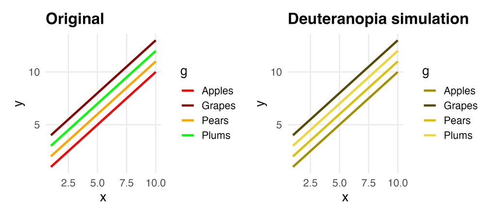

The categories that were distinct become indistinguishable.

## Rule 1: don’t encode meaning in color alone

```r
# Color + linetype: redundant encoding survives grayscale & colorblindness
ggplot(life_exp, aes(year, life_exp,
                     color = country,
                     linetype = country)) +
  geom_line(linewidth = 1.1) +
  geom_point(aes(shape = country), size = 2.5) +
  scale_color_viridis_d(end = 0.85) +
  labs(title = "Color + linetype + shape, three ways to tell them apart",
       x = NULL, y = "Years")
```

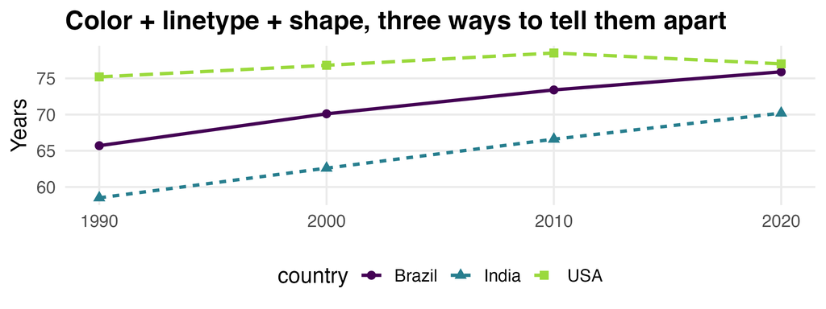

**The test:** print your figure in grayscale. Can you still read it?

## Rule 2: test what you ship

```r
# colorspace package: installed automatically with ggplot2 via the
# scales package, so you almost certainly have it already.
library(colorspace)

# Simulate any of three common color vision deficiencies on your plot:
deutan(c("red", "green", "blue"))   # deuteranopia (red-green)
protan(c("red", "green", "blue"))   # protanopia (red-green)
tritan(c("red", "green", "blue"))   # tritanopia (blue-yellow)

# For an interactive emulator on a full plot:
colorspace::cvd_emulator()
```

```r
# colorBlindness package: 6-panel side-by-side simulation
library(colorBlindness)
cvdPlot(my_plot)   # renders original + 5 deficiency simulations
```

## Rule 3: alt text + table fallbacks (Quarto)

For HTML / web output, add a `fig-alt` chunk option to every figure:

````markdown
---
title: "My report"
format: html
---

```r
#| label: fig-life-exp
#| fig-cap: "Life expectancy in three countries, 1990–2020"
#| fig-alt: "Line chart showing life expectancy rising steadily
#|   in Brazil and India but plateauing in the US between
#|   1990 and 2020."
ggplot(life_exp, ...) + ...
```
````

**Alt text describes the takeaway, not the chart type.**

A screen-reader user needs the *insight*, not “a line chart with three lines.”

## Accessibility quick checklist

**Color**

- Use viridis or Okabe-Ito by default
- Test with `colorspace::deutan()`
- Never encode meaning in color alone

**Text**

- ≥10pt captions, ≥12pt body, ≥14pt for projection
- Dark text on light bg (or vice versa)
- Avoid rotated text where possible

**Encoding**

- Color + shape, color + linetype
- Direct labels with `geom_text_repel()`
- Provide data table as fallback

**Output**

- Alt text on every figure (`fig-alt`)
- Tagged PDFs when possible
- Captions are not alt text

> **Color is supplemental. If your figure dies in grayscale, redesign it.**

# Demos 9–13, 18–19 · Maps in R

## The mental model

`▶ demos/09-map-basics-sf.R`

A map is **a data frame** where each row has a **`geometry`** column.

Once you accept that, the rest is just ggplot:

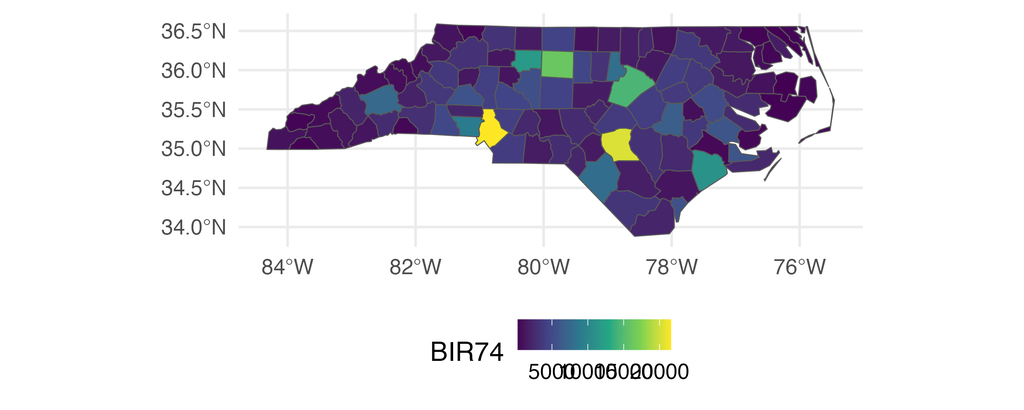

```r
library(sf)
# sf ships an example shapefile (North Carolina counties) — no download
nc <- st_read(system.file("shape/nc.shp", package = "sf"), quiet = TRUE)

ggplot(nc) +                     # nc is a data frame...
  geom_sf(aes(fill = BIR74)) +   # ...with a geometry column
  scale_fill_viridis_c()
```

That’s it. Everything else is detail.

## Where geometry comes from

```r
library(sf)       # the spatial foundation
library(tigris)   # US Census shapefiles
# library(tidycensus)    # for data + geometry in one call
# library(rnaturalearth) # world countries / states

options(tigris_use_cache = TRUE)  # cache shapefiles, saves enormous time

# US states
us_states <- tigris::states(cb = TRUE, year = 2024)

# US counties for a single state
wv_counties <- tigris::counties(state = "WV", cb = TRUE, year = 2024)

# World countries
# world <- rnaturalearth::ne_countries(returnclass = "sf")
```

**`cb = TRUE`** returns simplified “cartographic boundary” files, smaller, faster, fine for choropleths. Use full TIGER lines (`cb = FALSE`) only when you need precise boundaries.

The `year` argument controls the Census vintage. Omit it to use the latest available (currently 2024).

## Your first choropleth

`▶ demos/10-map-choropleth.R`

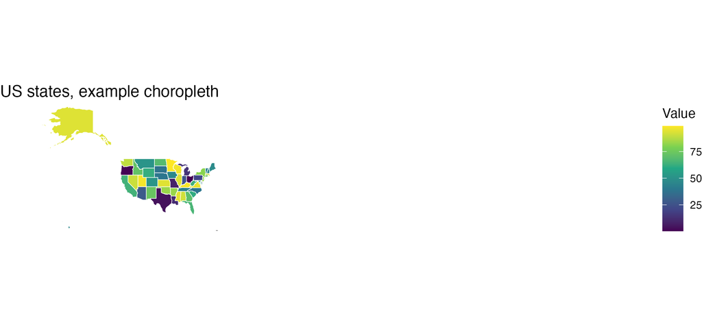

```r
library(sf)
library(tigris)
library(dplyr)
options(tigris_use_cache = TRUE)

# 1. Get the geometry
us_states <- states(cb = TRUE, year = 2024, resolution = "20m")

# 2. Make some data to join (here: random values; in practice your CSV)
my_data <- tibble(
  state_abbr = state.abb,
  value      = runif(50, 0, 100)
)

# 3. Join data to geometry
states_with_data <- us_states |>
  left_join(my_data, by = c("STUSPS" = "state_abbr"))

# 4. Plot
ggplot(states_with_data) +
  geom_sf(aes(fill = value), color = "white", linewidth = 0.2) +
  scale_fill_viridis_c(option = "D") +
  labs(title = "US states, example choropleth", fill = "Value") +
  theme_void()
```

## Real census data: WV counties with `tidycensus`

`▶ demos/19-census-wv-counties.R`

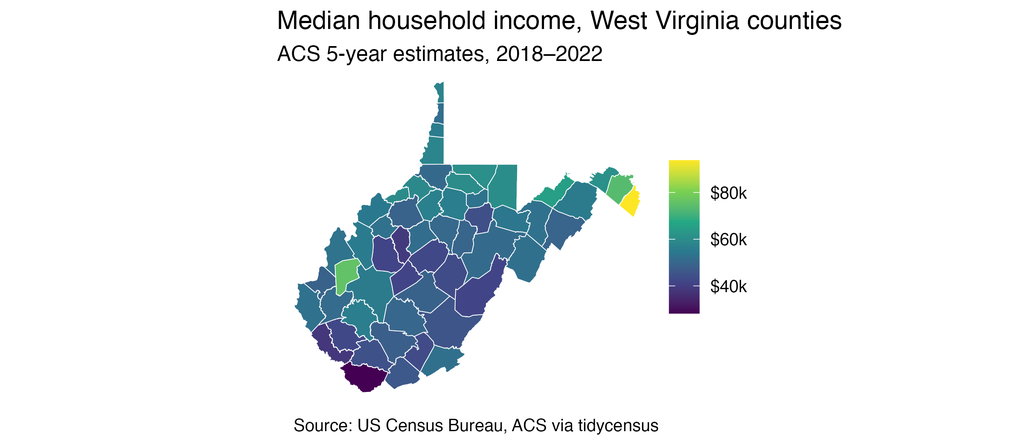

```r
library(tidycensus)   # data + geometry from the Census API in one call
library(ggplot2)

# Key comes from .Renviron (CENSUS_API_KEY); free signup at
# https://api.census.gov/data/key_signup.html
census_api_key(Sys.getenv("CENSUS_API_KEY"))

# B19013_001 = median household income (ACS 5-year)
wv_income <- get_acs(
  geography = "county",
  state     = "WV",
  variables = "B19013_001",
  year      = 2022,
  survey    = "acs5",
  geometry  = TRUE              # returns an sf data frame
)

ggplot(wv_income) +
  geom_sf(aes(fill = estimate), color = "white", linewidth = 0.2) +
  scale_fill_viridis_c(
    option = "D", labels = scales::label_dollar(scale = 1e-3, suffix = "k")
  ) +
  labs(
    title    = "Median household income, West Virginia counties",
    subtitle = "ACS 5-year estimates, 2018–2022",
    fill     = NULL,
    caption  = "Source: US Census Bureau, ACS via tidycensus"
  ) +
  theme_void(base_size = 12)
```

**`tidycensus::get_acs(geometry = TRUE)`** is the one call you usually want, it joins ACS data to TIGER geometry for you, no manual `left_join()` needed.

## Projections: the one that bites everyone

`▶ demos/11-map-projections.R`

```r
library(sf); library(tigris); library(dplyr)
options(tigris_use_cache = TRUE)
us_states <- states(cb = TRUE, year = 2024, resolution = "20m")
conus <- us_states |>                  # drop AK/HI/territories for the comparison
  filter(!STUSPS %in% c("AK", "HI", "PR", "GU", "VI", "MP", "AS"))
```

**Default (lon/lat / Web Mercator)**

Stretched. Areas not proportional.

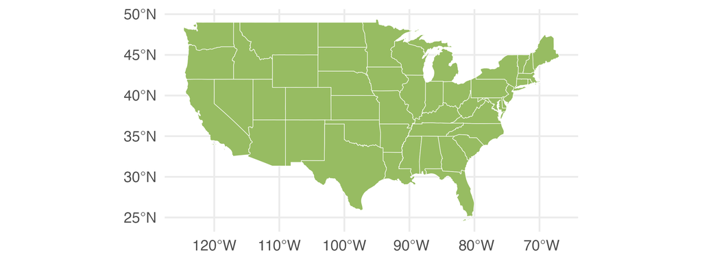

```r
ggplot(conus) +
  geom_sf(fill = "#97bc62", color = "white", linewidth = 0.2)
```

**Albers Equal Area (EPSG:5070)**

The right choice for continental US.

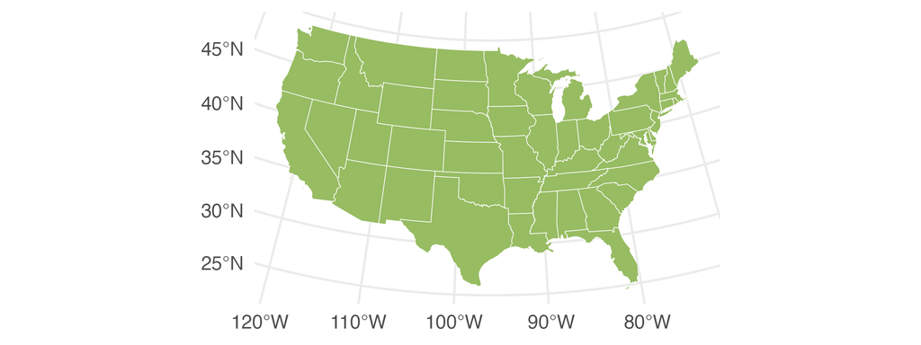

```r
ggplot(conus) +
  geom_sf(fill = "#97bc62", color = "white", linewidth = 0.2) +
  coord_sf(crs = "EPSG:5070")
```

**With Alaska + Hawaii rescaled**

`shift_geometry()` rescales them so the whole country fits.

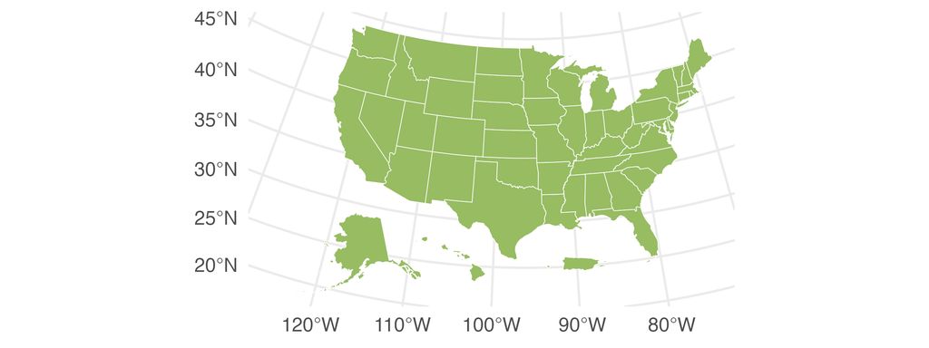

```r
us_states |>
  tigris::shift_geometry() |>
  ggplot() +
  geom_sf(fill = "#97bc62", color = "white", linewidth = 0.2) +
  coord_sf(crs = "EPSG:5070")
```

- Continental US → **EPSG:5070** (Albers Equal Area)
- World maps → **EPSG:8857** (Equal Earth) or **“+proj=robin”** (Robinson)
- Picking a projection for somewhere else → `crsuggest::suggest_crs()`

## Faceted comparison map

`▶ demos/12-map-faceted-comparison.R`

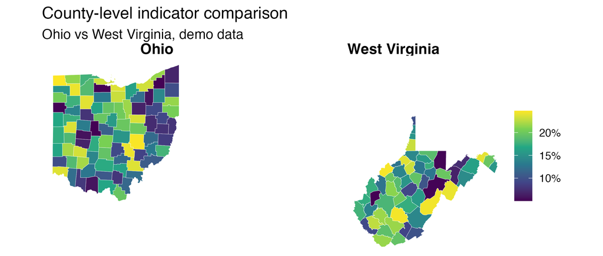

```r
# Compare two regions side by side: the "small multiples for maps" pattern
library(sf); library(tigris); library(dplyr); library(scales)
options(tigris_use_cache = TRUE)
set.seed(42)
two_states <- counties(state = c("WV", "OH"), cb = TRUE, year = 2024) |>
  mutate(state_name = if_else(STATEFP == "39", "Ohio", "West Virginia"),
         value      = runif(n(), 5, 25))    # demo data; your CSV in practice

ggplot(two_states) +
  geom_sf(aes(fill = value), color = "white", linewidth = 0.1) +
  scale_fill_viridis_c(option = "D", labels = label_number(suffix = "%")) +
  facet_wrap(~ state_name) +                # coord_sf() forbids scales = "free"
  labs(title    = "County-level indicator comparison",
       subtitle = "Ohio vs West Virginia, demo data",
       fill     = NULL) +
  theme_void(base_size = 13) +
  theme(strip.text = element_text(face = "bold", size = 14))
```

**`facet_wrap` works on maps the same way it works on regular plots.**

## Map polish: what separates competent from great

`▶ demos/13-map-polish.R`

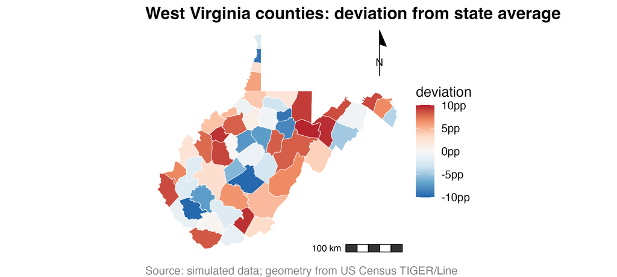

```r
library(sf); library(tigris); library(dplyr); library(scales)
library(ggspatial)   # scale bars and north arrows
options(tigris_use_cache = TRUE)
set.seed(42)
wv <- counties(state = "WV", cb = TRUE, year = 2024) |>
  mutate(deviation = runif(n(), -10, 10))    # deviation from state average

ggplot(wv) +
  geom_sf(aes(fill = deviation), color = "white", linewidth = 0.2) +
  # 1. Right scale type: diverging, because the data has a midpoint (0)
  scale_fill_distiller(palette = "RdBu", direction = -1,
                       limits = c(-10, 10), labels = label_number(suffix = "pp")) +
  # 2. Scale bar + north arrow, only when geographic precision matters
  annotation_scale(location = "br", bar_cols = c("grey20", "white")) +
  annotation_north_arrow(location = "tr", style = north_arrow_minimal()) +
  # 3. theme_void() drops axis chrome; 4. always caption the source
  labs(title   = "West Virginia counties: deviation from state average",
       caption = "Source: simulated data; geometry from US Census TIGER/Line") +
  theme_void(base_size = 13) +
  theme(plot.title   = element_text(face = "bold"),
        plot.caption = element_text(color = "grey50", hjust = 0))
```

> If you can make a ggplot, you can make a map. The data has a geometry column; everything else is the same.

## Rasters: when your data is a grid

`▶ demos/18-raster-basics.R`

Vectors (points / lines / polygons) cover most thematic maps. **Rasters** are the other half: a regular grid of cells, each holding a value. Think satellite imagery, elevation (DEMs), land cover, temperature, precipitation.

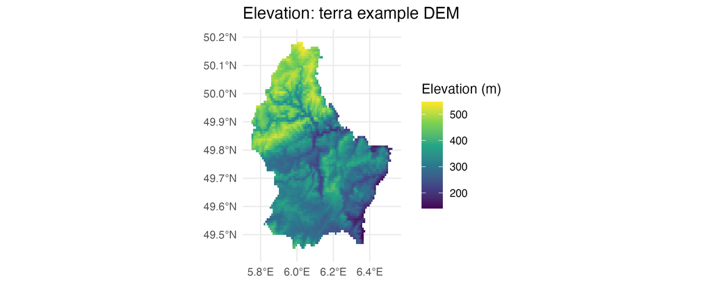

```r
library(terra)       # modern raster engine (successor to {raster})
library(tidyterra)   # ggplot geoms for SpatRaster

# terra ships an example DEM (elevation, Luxembourg) — no download
dem <- rast(system.file("ex/elev.tif", package = "terra"))

ggplot() +
  geom_spatraster(data = dem) +
  scale_fill_viridis_c(name = "Elevation (m)", na.value = NA) +
  labs(title = "Elevation: terra example DEM") +
  theme_minimal()
```

- **`terra`**: read, crop, mask, reproject, algebra; replaces older `raster` package
- **`stars`**: multi-dimensional raster cubes (time, bands); plays well with `sf`
- **`tidyterra`**: `geom_spatraster()` so rasters live inside the same ggplot grammar

> Same rules as vector maps, pick a perceptual scale, project sensibly, label the units.

# Demo 14 · Combining plots

## patchwork: `p1 + p2` is all you need to know

`▶ demos/14-patchwork.R`

```r
p_left <- ggplot(life_exp, aes(year, life_exp, color = country)) +
  geom_line(linewidth = 1) +
  scale_color_viridis_d(end = 0.85) +
  labs(title = "Trend", x = NULL, y = "Years")

p_right <- ggplot(life_exp |> filter(year == 2020),
                  aes(reorder(country, life_exp), life_exp, fill = country)) +
  geom_col() +
  scale_fill_viridis_d(end = 0.85, guide = "none") +
  labs(title = "2020 snapshot", x = NULL, y = "Years")

p_left + p_right
```

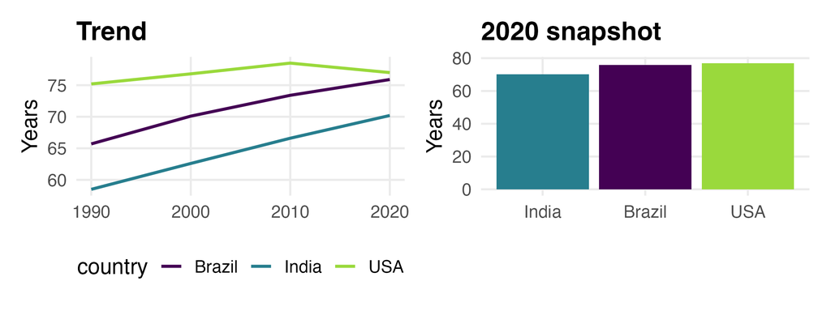

## More patchwork operators

```r
p1 + p2                                  # side by side
p1 / p2                                  # stacked
(p1 + p2) / p3                           # nesting
p1 | p2                                  # also side by side

# Shared annotation
(p1 + p2) +
  plot_annotation(
    title    = "Shared title",
    subtitle = "Across both panels",
    tag_levels = "A"                     # auto-label panels A, B, C...
  )

# Collect legends (so you only show one)
(p1 + p2) + plot_layout(guides = "collect")
```

You’ll see `gridExtra::grid.arrange()` in older code. **`patchwork` is the modern default.**

# Demo 15 · Exporting publication-quality output

## `ggsave`: the arguments that matter

`▶ demos/15-ggsave-export.R`

```r
ggsave(
  filename = "fig-1.png",
  plot     = p,
  width    = 7,      # build at FINAL size, don't rescale later
  height   = 4,
  units    = "in",
  dpi      = 300,    # 300 for print, 150 for screen
  device   = ragg::agg_png   # ragg handles fonts correctly
)

# For PDF: use cairo_pdf to embed fonts properly
ggsave("fig-1.pdf", plot = p,
       width = 7, height = 4, units = "in",
       device = cairo_pdf)

# For vector that scales infinitely (web, illustrator)
ggsave("fig-1.svg", plot = p, width = 7, height = 4, units = "in")
```

## Export pitfalls

- **Resizing in Word/PowerPoint after export**: text gets warped. Set the size in `ggsave`.
- **Fonts substituting in PDF**: use `device = cairo_pdf`
- **PNG blurry when zoomed**: use SVG or PDF for vector
- **“Looks fine on my laptop, terrible on the projector”**: always test
- **Different output on different OS**: `ragg` minimizes this; old `png()` doesn’t

> **Build the figure at its final size. Don’t rescale.**

# Demo 16 · Common pitfalls

## Misleading visualizations to avoid

`▶ demos/16-common-pitfalls.R`

- **Truncated y-axis on bar charts**: bars no longer represent magnitude
- **Dual y-axes**: almost always misleading; one of them is a lie
- **Pie charts beyond 3 slices**: humans can’t compare angles
- **3D anything**: perspective distorts area
- **Rainbow / jet colormaps**: perceptually non-uniform; fail under colorblindness
- **Encoding ordering in hue alone**: luminance carries ordering, hue doesn’t
- **More gridlines than data points**: declutter
- **Tiny axis labels on big figures**: readable at *final* size

## Portability and reproducibility pitfalls

- **Hardcoded file paths** (`/Users/me/...`) → use `here::here("data", "file.csv")`
- **`setwd()` anywhere in code** → use RStudio projects
- **“It worked yesterday”** → `renv::snapshot()` locks package versions
- **Random seeds not set** → `set.seed(42)` whenever randomness is involved
- **No `sessionInfo()`** → put it at the end of every analysis file

> **Future-you and reviewer-you are different people. Code for both.**

# Demo 17 · Reproducibility

## Make it run on someone else’s laptop

`▶ demos/17-reproducibility.R`

- **RStudio projects**: never `setwd()`; let the project anchor everything
- **`here::here("data", "file.csv")`**: paths that work regardless of where the script runs
- **`renv`**: lockfile of every package version, like Python’s `requirements.txt`
- **`sessionInfo()`** at the end of every notebook
- **Git**: even just `git init` is better than nothing
- **A README**: what this project does, how to install, how to run

> **If you can’t hand your project to a stranger and have it run in 10 minutes, it’s not done.**

## A minimal reproducible setup

```r
# At the top of every analysis script:
library(here)
library(tidyverse)
library(sf)

set.seed(42)

# Use here() for every path
data <- read_csv(here("data", "raw", "my-data.csv"))

# At the bottom:
sessionInfo()
```

```r
# In the R console, once per project:
renv::init()        # set up renv
renv::snapshot()    # lock current package versions to renv.lock

# On another machine, to install the same versions:
renv::restore()
```

# Demo 20 · Beyond static

## When static isn’t enough

`▶ demos/20-interactive-plotly.R`

```r
# Turn any ggplot into an interactive HTML widget in one line
library(plotly)
ggplotly(p)
```

```r
# Interactive web maps (tile-based, like Google Maps)
library(leaflet)
leaflet(my_sf_data) |>
  addTiles() |>
  addPolygons(fillColor = ~viridis::viridis(10)[as.numeric(cut(value, 10))])
```

- **`plotly::ggplotly()`**: quickest path to interactive
- **`leaflet`**: interactive maps with tile basemaps
- **`shiny`**: full apps where readers filter / parameterize
- **`tmap`**: alternative mapping framework (v4 in 2025; “thematic maps”, switches between static and interactive)

**Caveat:** interactive ≠ better. For a printed report, static is correct.

# Demo 21 · Capstone

## Putting it all together

`▶ demos/21-infographic.R`

Every demo taught one move. The last step is **assembly**, chaining them into a single figure that stands on its own.

```r
# One tidy table -> three complementary views, composed with patchwork
figure <- (p_trend) / (p_rank | p_map) +
  plot_layout(heights = c(1.4, 1)) +
  plot_annotation(
    title    = "Two decades of gains across three states",
    subtitle = "A worked example: one tidy table, three views",
    caption  = "Built in R with ggplot2 + patchwork"
  )

ggsave(here("figures", "capstone-infographic.png"),
       figure, device = ragg::agg_png,
       width = 9, height = 7.5, units = "in", dpi = 300)
```

The pipeline, end to end: **tidy data** → a **trend** + a **ranked bar** + a **locator map** → composed, **branded**, and **exported** at a fixed size and DPI so it looks identical everywhere.

**The point:** communication is just assembly. The skill is choosing which views answer the reader’s question, then making the result *stand alone*.

# Wrap-up

## Useful R packages: a quick tour

**Core plotting**

- **`ggplot2`**: the grammar-of-graphics plotting system
- **`scales`**: axis formatting, transformations, palettes
- **`patchwork`**: combine plots with `+` and `/`
- **`ggrepel`**: labels that don’t overlap

**Color**

- **`viridis`**: perceptually-uniform palettes
- **`colorspace`**: color manipulation + CVD simulation
- **`RColorBrewer`**: the ColorBrewer palettes

**Spatial / maps**

- **`sf`**: vector spatial data as tidy data frames
- **`tigris`**: US Census TIGER shapefiles
- **`tidycensus`**: Census/ACS data with geometry attached
- **`terra`** + **`tidyterra`**: rasters, in ggplot
- **`ggspatial`**: scale bars, north arrows

**Output & interactivity**

- **`ragg`**: fast, high-quality graphics device
- **`plotly`**: turn a ggplot interactive in one line
- **`gt`**: publication-quality tables

**Workflow:** **`here`** (sane paths) · **`renv`** (lock package versions) · **`quarto`** (reproducible documents)

## Resources & books

**Books (all free online)**

- [R for Data Science (2e)](https://r4ds.hadley.nz/): Wickham, Çetinkaya-Rundel, Grolemund
- [ggplot2: Elegant Graphics for Data Analysis (3e)](https://ggplot2-book.org/), Wickham et al.
- [Geocomputation with R](https://r.geocompx.org/): Lovelace, Nowosad, Muenchow
- [Analyzing US Census Data](https://walker-data.com/census-r/), Walker
- [Spatial Data Science (sf/stars)](https://r-spatial.org/book/), Pebesma, Bivand
- [Advanced R (2e)](https://adv-r.hadley.nz/), Wickham
- [Happy Git and GitHub for the useR](https://happygitwithr.com/), Bryan

**Galleries & inspiration**

- [R Graph Gallery](https://r-graph-gallery.com/)
- [ggplot2 extensions gallery](https://exts.ggplot2.tidyverse.org/gallery/)
- [#TidyTuesday](https://github.com/rfordatascience/tidytuesday), weekly community challenge

**Accessibility**

- [Color Universal Design (Okabe-Ito)](https://jfly.uni-koeln.de/color/)
- [WCAG 2.1 quick reference](https://www.w3.org/WAI/WCAG21/quickref/)

**Quarto**

- [quarto.org/docs/guide](https://quarto.org/docs/guide/)

# Questions?

Slides, demo `.R` files, and live-coding companion at:

[**github.com/SiddharthaSBora/r-dataviz-webinar**](https://github.com/SiddharthaSBora/r-dataviz-webinar)